# Untitled

May 3, 2019

# install.packages(‘xgboost’)

# Project II

- I have added layered tabs.
  - please make sure to scroll through secondary tabs in each category

## exploration

### Notes from EDA

```
+ Some clear multicolinearity issues(see corrplot section)
+ last 3 columns seems to share identical correlations with other prdictors
+ some of Hydrolic pressure have high correlation
+ Bailing Density, have high correlations with each other and last 3 variables
+ carb temp and Carb pressure share high correlation with each other
+ Our variables dont have very strong correlation scores with ph
+ Carb rel seems to have higheest correltaion, might be one oflast 3 columns to keep
+ MNF flow has highest correltion with PH(negative)
+ Brand 'B' has the most frequency followed by Brand 'D'.
+ From the Histogram we can see Hyd.Pressure1, Hyd.Press2,Hyd.Pressure3, Carb.Flow and Balling has some really lpw values.
+ Some of the variables like Usage.count are skewed and also has outliers.
+ Differences exist among brands by Density, Balling, and Balling Lvl
+ From the Density plots we can see the distribution is not uniform for some of the variables like Hyd.Pressure1, Hyd.Press2, and Hyd.Pressure3.
+ Removing the 4 records with null PH value
+ Rounded PSC.CO2 and Pressure.setpoint
```

```r
df <- read.xlsx("train.xlsx",1)
df = subset(df, !is.na(PH))
df$Pressure.Setpoint = round(df$Pressure.Setpoint, 0)
df$PSC.CO2 = round(df$PSC.CO2, 2)
test <- read.xlsx("test.xlsx",1)
```

### Look at the Brand differences

```
##                     Brand_A   Brand_B   Brand_C   Brand_D  Brand_Na
## Carb.Volume          5.4257    5.3126    5.3002    5.5104    5.2909
## Fill.Ounces         23.9821   23.9778   23.9849   23.9566   23.9971
## PC.Volume            0.2688    0.2827    0.2902    0.2617    0.2888
## Carb.Pressure       69.2804   67.1962   66.9248   70.6982   66.2605
## Carb.Temp          141.2288  141.1052  141.0536  141.1301  140.5179
## PSC                  0.0776    0.0865    0.0898    0.0806    0.0904
## PSC.Fill             0.1984    0.1936    0.2103    0.1910    0.1893
## PSC.CO2              0.0555    0.0571    0.0621    0.0528    0.0559
## Mnf.Flow            39.7147   20.5757   23.2809   25.7467   27.1533
## Carb.Pressure1     122.8186  122.4415  122.1940  122.7236  123.4605
## Fill.Pressure       48.2212   48.1701   48.2287   46.9612   48.7829
## Hyd.Pressure1       12.9024   12.5657   12.3283   12.3967   10.8900
## Hyd.Pressure2       21.1582   21.1731   19.1625   21.9733   18.4367
## Hyd.Pressure3       20.9747   20.2321   19.0467   21.5901   19.7867
## Hyd.Pressure4      101.2837  100.1059  102.5400   83.4528   95.9828
## Filler.Level       108.6267  107.9616  111.6020  110.4226  112.1508
## Filler.Speed      3582.0772 3732.5359 3673.6622 3688.9767 3517.8291
## Temperature         66.0632   65.8851   66.7166   65.4621   67.2269
## Usage.cont          21.1403   20.9688   21.0366   21.0065   20.7293
## Carb.Flow         2387.3540 2540.5911 2311.5395 2437.1805 2557.4333
## Density              1.5711    0.9095    0.9222    1.6825    0.9687
## MFR                704.9837  705.6386  704.0283  703.9763  685.1028
## Balling              3.1990    1.5138    1.6317    3.4856    1.6708
## Pressure.Vacuum     -5.2389   -5.1543   -5.3105   -5.2602   -5.3333
## PH                   8.4974    8.5668    8.4137    8.6025    8.4888
## Oxygen.Filler        0.0415    0.0470    0.0516    0.0450    0.0473
## Bowl.Setpoint      109.1134  107.7976  111.6184  110.8878  112.1667
## Pressure.Setpoint   47.7629   47.9393   48.0337   46.6460   47.7983
## Air.Pressurer      142.7358  142.9598  142.7664  142.6930  142.6717
## Alch.Rel             7.1349    6.5508    6.5649    7.6935    6.6415
## Carb.Rel             5.5177    5.3621    5.3524    5.6073    5.3442
## Balling.Lvl          3.0771    1.4074    1.5206    3.2321    1.4687
```

### Density Plots

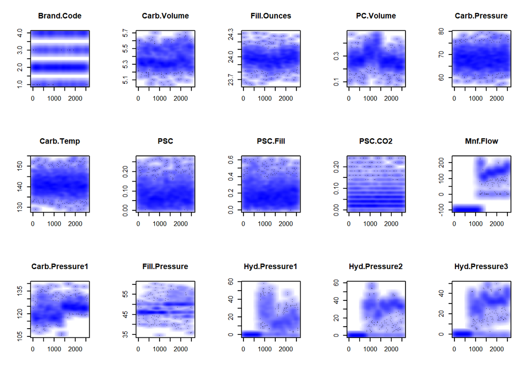

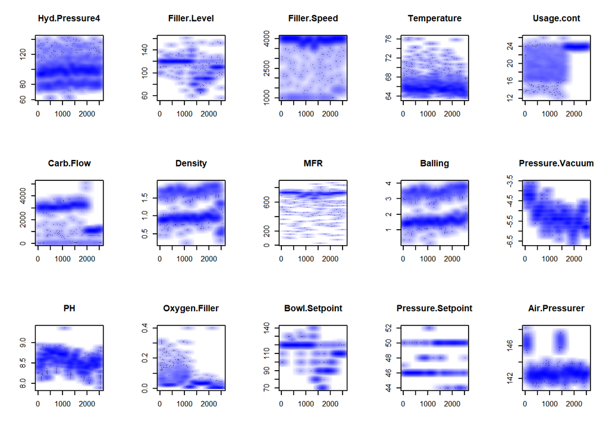

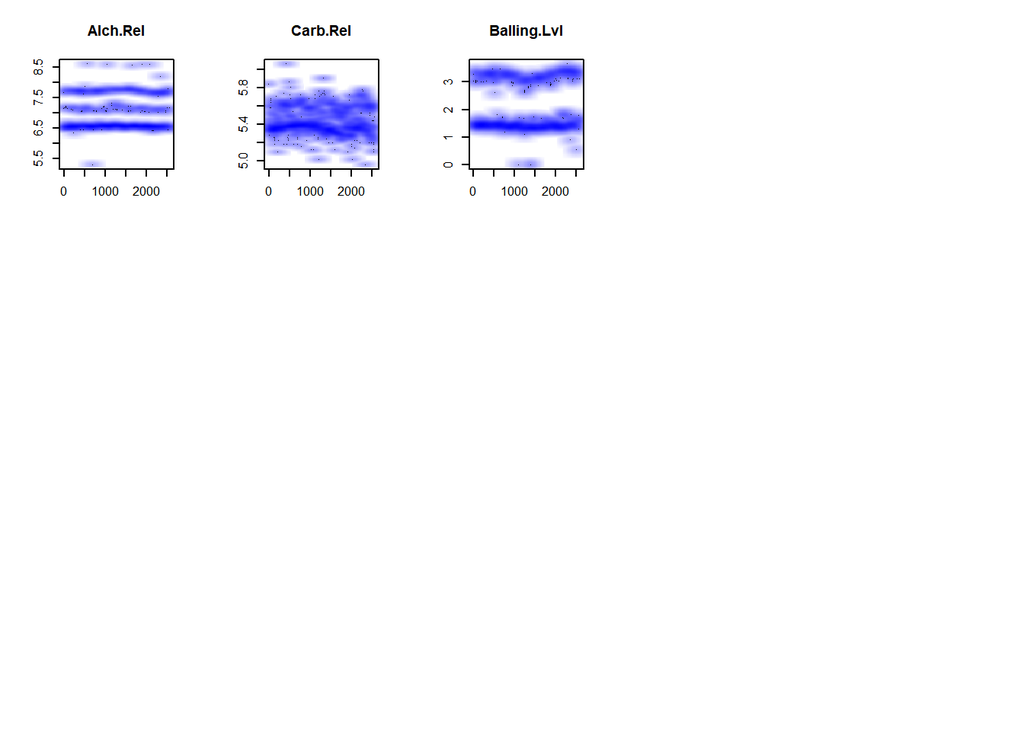

### Look at entire dataset and PH

|  | vars | n | mean | sd | median | trimmed | mad | min | max | range | skew | kurtosis | se |
| --- | --- | --- | --- | --- | --- | --- | --- | --- | --- | --- | --- | --- | --- |
| Brand.Code* | 1 | 2447 | 2.51 | 1.00 | 2.00 | 2.51 | 0.00 | 1.00 | 4.00 | 3.00 | 0.38 | -1.06 | 0.02 |
| Carb.Volume | 2 | 2557 | 5.37 | 0.11 | 5.35 | 5.37 | 0.11 | 5.04 | 5.70 | 0.66 | 0.39 | -0.47 | 0.00 |
| Fill.Ounces | 3 | 2529 | 23.97 | 0.09 | 23.97 | 23.98 | 0.08 | 23.63 | 24.32 | 0.69 | -0.02 | 0.87 | 0.00 |
| PC.Volume | 4 | 2528 | 0.28 | 0.06 | 0.27 | 0.27 | 0.05 | 0.08 | 0.48 | 0.40 | 0.35 | 0.67 | 0.00 |
| Carb.Pressure | 5 | 2540 | 68.19 | 3.54 | 68.20 | 68.12 | 3.56 | 57.00 | 79.40 | 22.40 | 0.18 | -0.01 | 0.07 |
| Carb.Temp | 6 | 2541 | 141.09 | 4.03 | 140.80 | 140.99 | 3.85 | 128.60 | 154.00 | 25.40 | 0.24 | 0.23 | 0.08 |
| PSC | 7 | 2534 | 0.08 | 0.05 | 0.08 | 0.08 | 0.05 | 0.00 | 0.27 | 0.27 | 0.85 | 0.65 | 0.00 |
| PSC.Fill | 8 | 2544 | 0.20 | 0.12 | 0.18 | 0.18 | 0.12 | 0.00 | 0.62 | 0.62 | 0.94 | 0.77 | 0.00 |
| PSC.CO2 | 9 | 2528 | 0.06 | 0.04 | 0.04 | 0.05 | 0.03 | 0.00 | 0.24 | 0.24 | 1.73 | 3.72 | 0.00 |
| Mnf.Flow | 10 | 2567 | 24.63 | 119.50 | 70.20 | 21.14 | 161.60 | -100.20 | 229.40 | 329.60 | 0.00 | -1.87 | 2.36 |
| Carb.Pressure1 | 11 | 2535 | 122.57 | 4.73 | 123.20 | 122.53 | 4.45 | 105.60 | 140.20 | 34.60 | 0.04 | 0.13 | 0.09 |
| Fill.Pressure | 12 | 2549 | 47.92 | 3.18 | 46.40 | 47.71 | 2.37 | 34.60 | 60.40 | 25.80 | 0.55 | 1.41 | 0.06 |
| Hyd.Pressure1 | 13 | 2556 | 12.46 | 12.43 | 11.40 | 10.86 | 16.90 | -0.80 | 58.00 | 58.80 | 0.78 | -0.14 | 0.25 |
| Hyd.Pressure2 | 14 | 2552 | 20.99 | 16.38 | 28.60 | 21.09 | 13.34 | 0.00 | 59.40 | 59.40 | -0.31 | -1.56 | 0.32 |
| Hyd.Pressure3 | 15 | 2552 | 20.48 | 15.97 | 27.60 | 20.53 | 13.79 | -1.20 | 50.00 | 51.20 | -0.32 | -1.57 | 0.32 |
| Hyd.Pressure4 | 16 | 2539 | 96.31 | 13.10 | 96.00 | 95.46 | 11.86 | 62.00 | 142.00 | 80.00 | 0.56 | 0.61 | 0.26 |
| Filler.Level | 17 | 2551 | 109.25 | 15.70 | 118.40 | 111.04 | 9.19 | 55.80 | 161.20 | 105.40 | -0.85 | 0.05 | 0.31 |
| Filler.Speed | 18 | 2513 | 3688.11 | 769.63 | 3982.00 | 3920.25 | 47.44 | 998.00 | 4030.00 | 3032.00 | -2.88 | 6.75 | 15.35 |
| Temperature | 19 | 2555 | 65.96 | 1.38 | 65.60 | 65.80 | 0.89 | 63.60 | 76.20 | 12.60 | 2.39 | 10.25 | 0.03 |
| Usage.cont | 20 | 2562 | 20.99 | 2.98 | 21.79 | 21.25 | 3.19 | 12.08 | 25.90 | 13.82 | -0.54 | -1.02 | 0.06 |
| Carb.Flow | 21 | 2565 | 2472.05 | 1070.43 | 3030.00 | 2604.15 | 323.21 | 26.00 | 5104.00 | 5078.00 | -0.99 | -0.57 | 21.14 |
| Density | 22 | 2567 | 1.17 | 0.38 | 0.98 | 1.15 | 0.15 | 0.24 | 1.92 | 1.68 | 0.53 | -1.21 | 0.01 |
| MFR | 23 | 2359 | 704.05 | 73.90 | 724.00 | 718.16 | 15.42 | 31.40 | 868.60 | 837.20 | -5.09 | 30.46 | 1.52 |
| Balling | 24 | 2567 | 2.20 | 0.93 | 1.65 | 2.13 | 0.37 | 0.16 | 4.01 | 3.85 | 0.60 | -1.40 | 0.02 |
| Pressure.Vacuum | 25 | 2567 | -5.22 | 0.57 | -5.40 | -5.25 | 0.59 | -6.60 | -3.60 | 3.00 | 0.53 | -0.03 | 0.01 |
| PH | 26 | 2567 | 8.55 | 0.17 | 8.54 | 8.55 | 0.18 | 7.88 | 9.36 | 1.48 | -0.29 | 0.06 | 0.00 |
| Oxygen.Filler | 27 | 2556 | 0.05 | 0.05 | 0.03 | 0.04 | 0.02 | 0.00 | 0.40 | 0.40 | 2.41 | 8.84 | 0.00 |
| Bowl.Setpoint | 28 | 2565 | 109.35 | 15.29 | 120.00 | 111.36 | 0.00 | 70.00 | 140.00 | 70.00 | -0.97 | -0.05 | 0.30 |
| Pressure.Setpoint | 29 | 2555 | 47.61 | 2.04 | 46.00 | 47.60 | 0.00 | 44.00 | 52.00 | 8.00 | 0.20 | -1.60 | 0.04 |
| Air.Pressurer | 30 | 2567 | 142.83 | 1.21 | 142.60 | 142.58 | 0.59 | 140.80 | 148.20 | 7.40 | 2.25 | 4.73 | 0.02 |
| Alch.Rel | 31 | 2560 | 6.90 | 0.51 | 6.56 | 6.84 | 0.06 | 5.28 | 8.62 | 3.34 | 0.88 | -0.85 | 0.01 |
| Carb.Rel | 32 | 2559 | 5.44 | 0.13 | 5.40 | 5.43 | 0.12 | 4.96 | 6.06 | 1.10 | 0.50 | -0.30 | 0.00 |
| Balling.Lvl | 33 | 2566 | 2.05 | 0.87 | 1.48 | 1.98 | 0.21 | 0.00 | 3.66 | 3.66 | 0.59 | -1.50 | 0.02 |

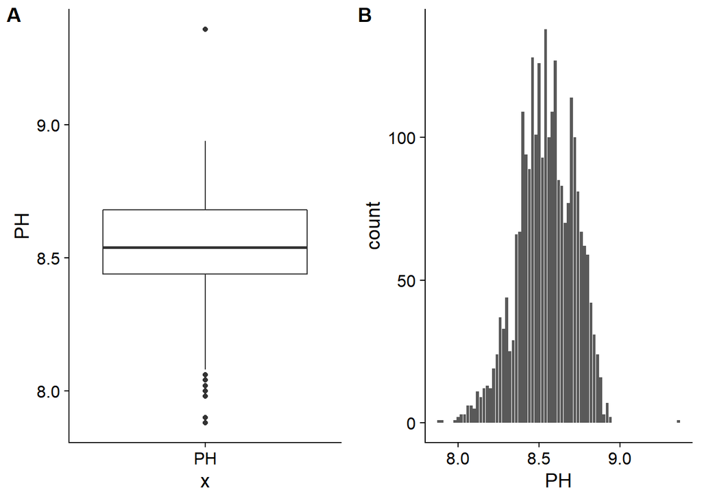

#### Display PH is null training data observations

```r
## Grab observations where PH is NA
kable(df[(which(is.na(df$PH))),],digits =2,'markdown',booktabs =T)
```

| Brand.Code | Carb.Volume | Fill.Ounces | PC.Volume | Carb.Pressure | Carb.Temp | PSC | PSC.Fill | PSC.CO2 | Mnf.Flow | Carb.Pressure1 | Fill.Pressure | Hyd.Pressure1 | Hyd.Pressure2 | Hyd.Pressure3 | Hyd.Pressure4 | Filler.Level | Filler.Speed | Temperature | Usage.cont | Carb.Flow | Density | MFR | Balling | Pressure.Vacuum | PH | Oxygen.Filler | Bowl.Setpoint | Pressure.Setpoint | Air.Pressurer | … |
| --- | --- | --- | --- | --- | --- | --- | --- | --- | --- | --- | --- | --- | --- | --- | --- | --- | --- | --- | --- | --- | --- | --- | --- | --- | --- | --- | --- | --- | --- | --- |

### Look at our brand code factor column

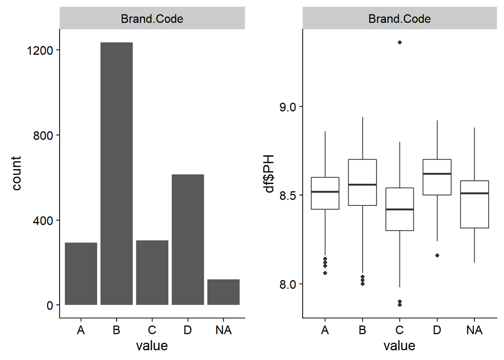

```r
## Visualizations for Brand code factor column
a <- df %>%
  select_if(is.factor) %>%
  gather %>%
  ggplot(aes(x = value)) +
  geom_histogram(stat='count') +
  facet_wrap(~key)
b <- df %>%
  select_if(is.factor) %>%
  gather %>%
  ggplot(aes(x = value)) +
  geom_boxplot(aes(x = df$Brand.Code,y = df$PH)) +
  facet_wrap(~key)

plot_grid(a,b)
```

### Corrplots

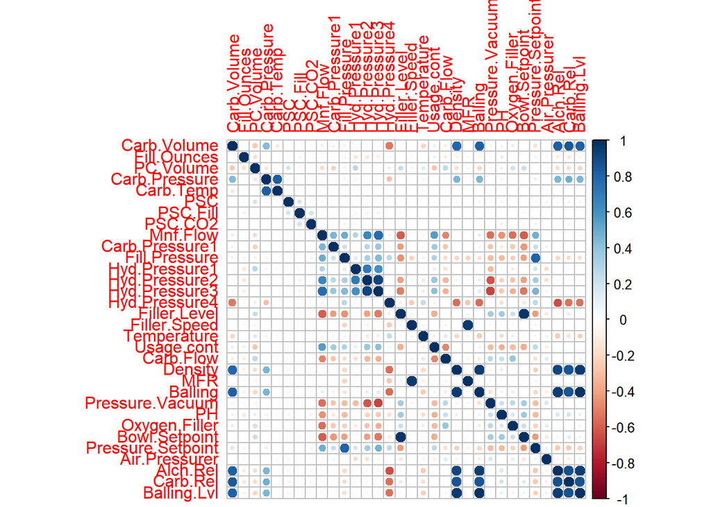

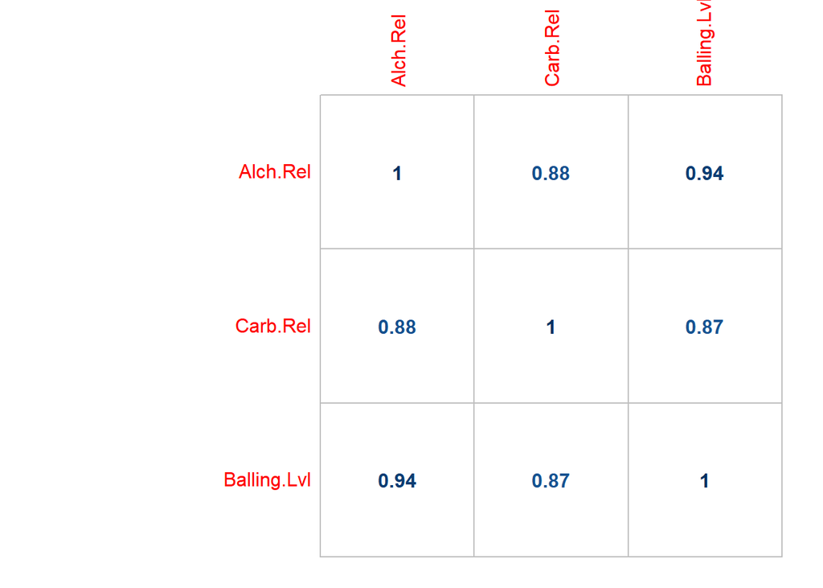

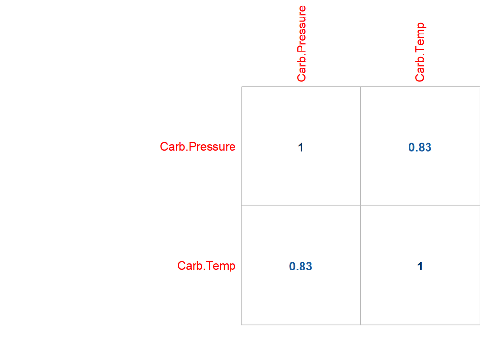

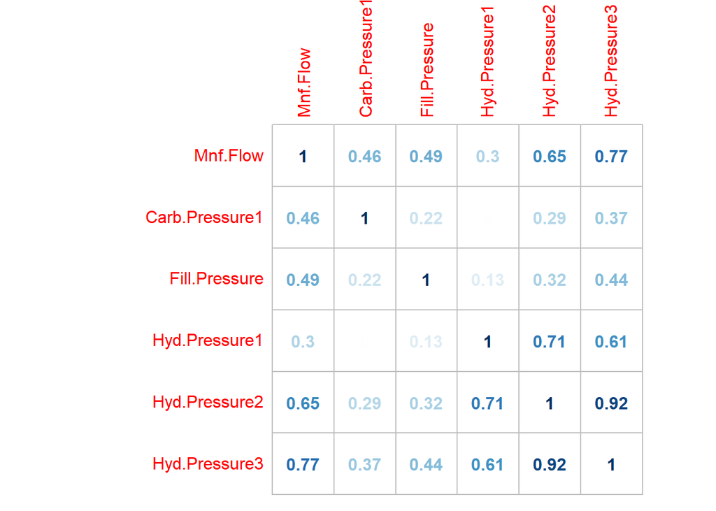

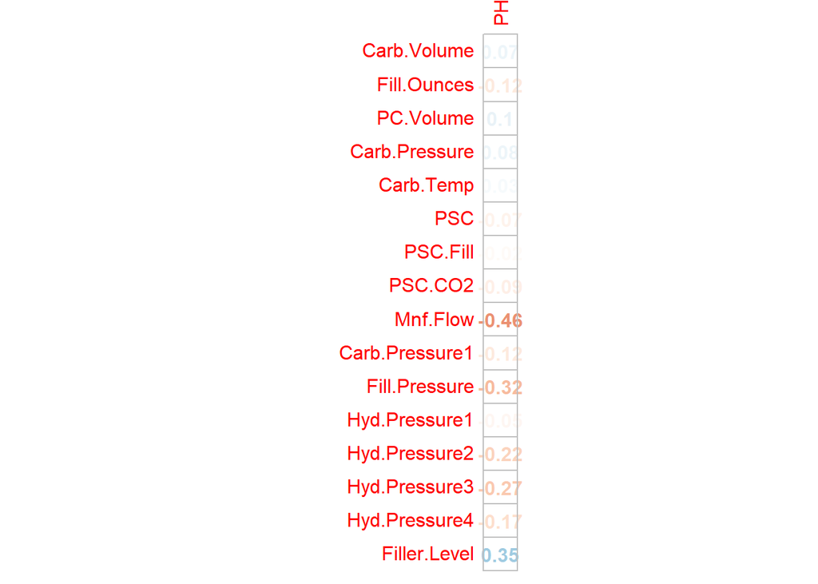

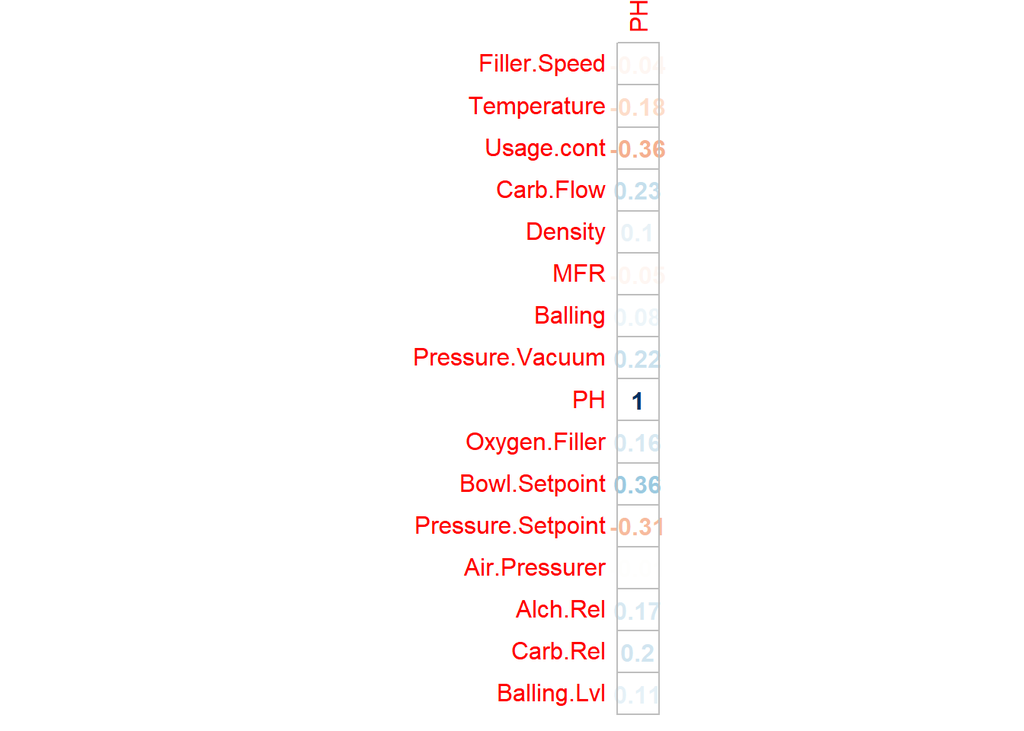

### Looking at PH scatterplots versus predictors and histograms of predictors

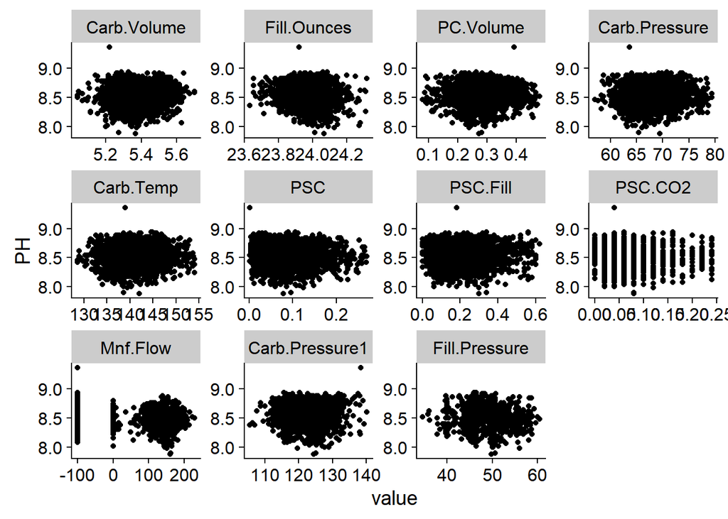

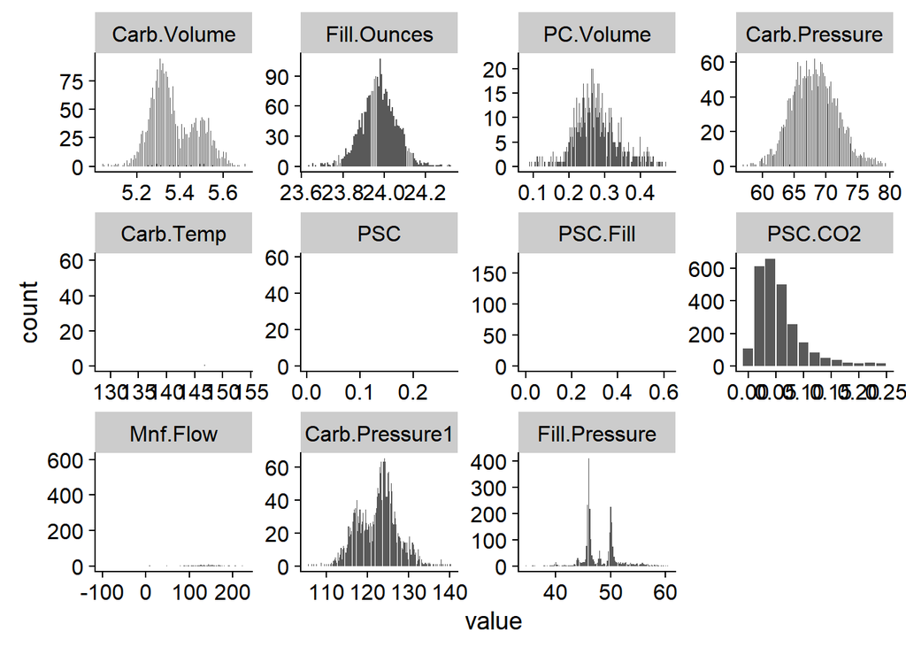

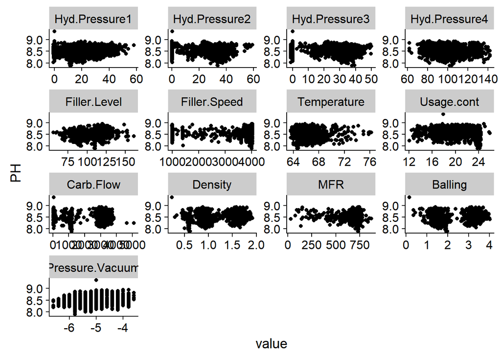

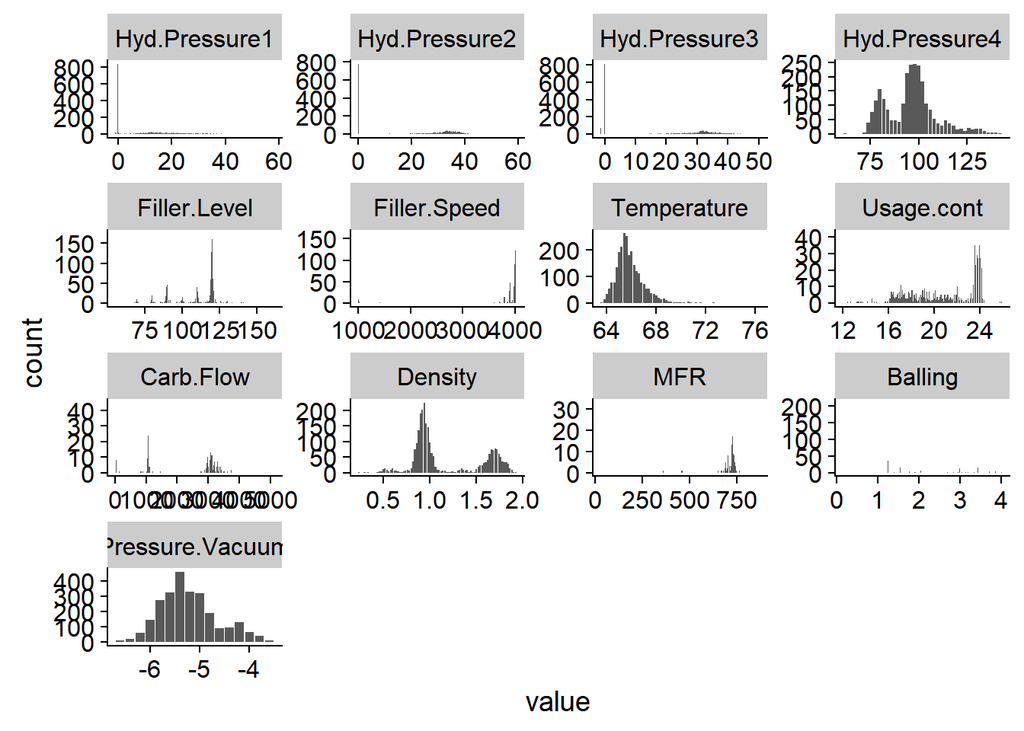

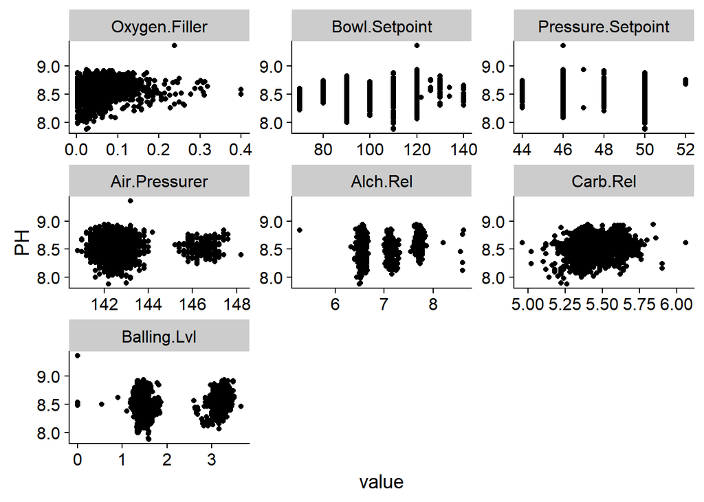

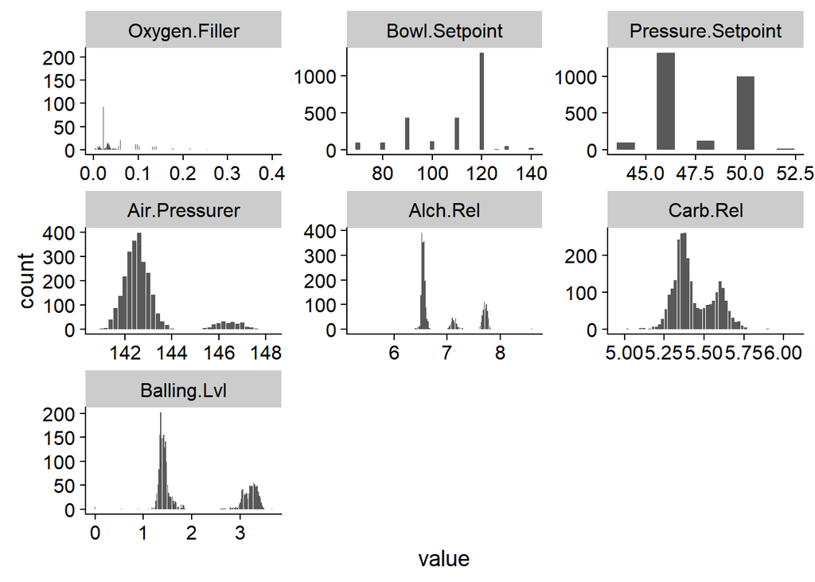

### variables that seem discrete

- Bowl.Setpoint
- Pressure.Setpoint
- PSC.CO2

```r
kable(table(df$Bowl.Setpoint), digits = 2,'markdown', booktabs =T)
```

| Var1 | Freq |
| --- | --- |
| 70 | 98 |
| 80 | 96 |
| 90 | 433 |
| 100 | 112 |
| 110 | 436 |
| 120 | 1306 |
| 122 | 1 |
| 126 | 10 |
| 130 | 51 |
| 134 | 2 |
| 140 | 20 |

```r
kable(table(df$Pressure.Setpoint), digits = 2, 'markdown', booktabs =T)
```

| Var1 | Freq |
| --- | --- |
| 44 | 96 |
| 46 | 1322 |
| 47 | 2 |
| 48 | 125 |
| 50 | 999 |
| 52 | 11 |

```r
kable(table(df$PSC.CO2), digits = 2, 'markdown',booktabs =T)
```

| Var1 | Freq |
| --- | --- |
| 0 | 108 |
| 0.02 | 612 |
| 0.04 | 659 |
| 0.06 | 501 |
| 0.08 | 257 |
| 0.1 | 144 |
| 0.12 | 82 |
| 0.14 | 49 |
| 0.16 | 39 |
| 0.18 | 20 |
| 0.2 | 18 |
| 0.22 | 22 |
| 0.24 | 17 |

#### Rounding

- I rounded PSC.CO2 and Pressure.setpoint. I don’t think these changes will make any difference in modeling results(all seem distributed evenly around the mean of PH), but I think we should still include it in EDA as it shows how “deeply” we looked into the data.

```r
df$PSC.CO2 <- round(df$PSC.CO2,2)
## rounded new table for PSC CO2
table(df$PSC.CO2)
```

```
##
##    0 0.02 0.04 0.06 0.08  0.1 0.12 0.14 0.16 0.18  0.2 0.22 0.24
##  108  612  659  501  257  144   82   49   39   20   18   22   17
```

```r
## rounded to integer new table for Pressure setpoint
df$Pressure.Setpoint <- round(df$Pressure.Setpoint,0)
table(df$Pressure.Setpoint)
```

```
##
##   44   46   47   48   50   52
##   96 1322    2  125  999   11
```

#### PSC.CO2 and Pressure.setpoint

- Scatterplots with new rounded off data

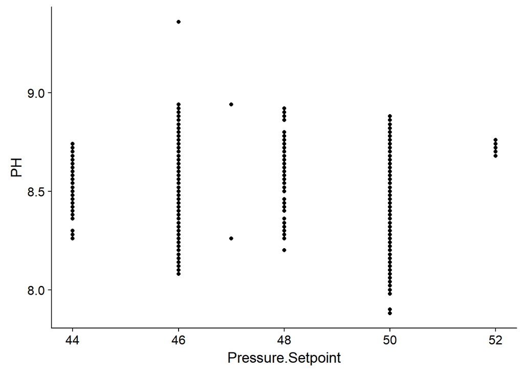

```r
## After rounding visualize Pressure.Setpoint
ggplot(df, aes(Pressure.Setpoint, PH)) +
  geom_point()
```

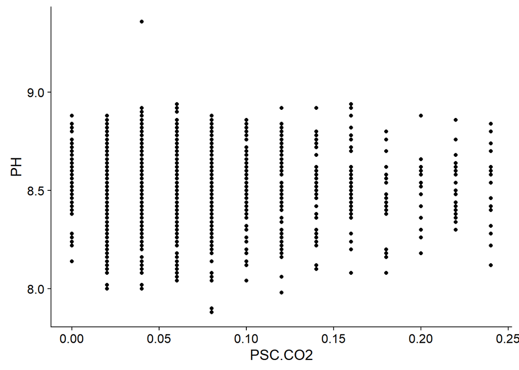

```r
## After rounding visualize PSC.CO2
ggplot(df, aes(PSC.CO2, PH)) +
  geom_point()
```

#### bowl.Setpoint predictor

- Setpoint seems to sequence by 10 integers, and then has random integers towards the end. I filtered for those random observations to see any trend. I then visualize the variable. I don’t believe we need to make any changes to it

```r
df %>%
    filter(Bowl.Setpoint> 120 & Bowl.Setpoint <130) %>%
    dplyr::select(PH)
```

```
##      PH
## 1  8.74
## 2  8.74
## 3  8.74
## 4  8.76
## 5  8.62
## 6  8.62
## 7  8.60
## 8  8.62
## 9  8.56
## 10 8.58
## 11 8.44
```

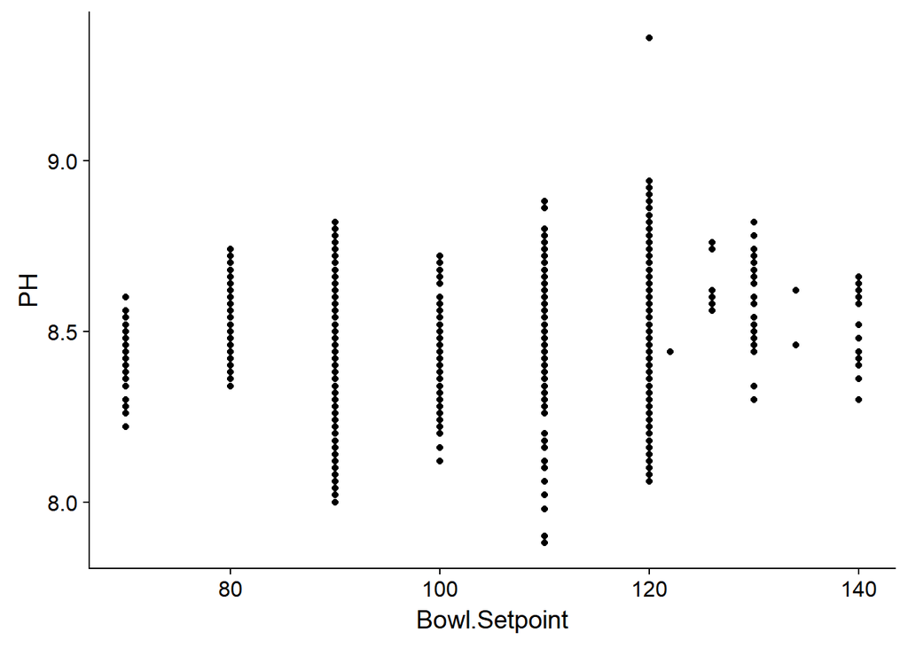

```r
ggplot(df, aes(Bowl.Setpoint, PH)) +
  geom_point()
```

### Imputation and visualizing missing data

- The rest of the analysis would require the imputed csv

```r
## missing values
pMiss <- function(x){sum(is.na(x))/length(x)}
apply(df,2,pMiss)
```

```
##        Brand.Code       Carb.Volume       Fill.Ounces         PC.Volume
##      0.0467471757      0.0038955980      0.0148032723      0.0151928321
##     Carb.Pressure         Carb.Temp               PSC          PSC.Fill
##      0.0105181145      0.0101285547      0.0128554733      0.0089598753
##           PSC.CO2          Mnf.Flow    Carb.Pressure1     Fill.Pressure
##      0.0151928321      0.0000000000      0.0124659135      0.0070120764
##     Hyd.Pressure1     Hyd.Pressure2     Hyd.Pressure3     Hyd.Pressure4
##      0.0042851578      0.0058433970      0.0058433970      0.0109076743
##      Filler.Level      Filler.Speed       Temperature        Usage.cont
##      0.0062329568      0.0210362291      0.0046747176      0.0019477990
##         Carb.Flow           Density               MFR           Balling
##      0.0007791196      0.0000000000      0.0810284379      0.0000000000
##   Pressure.Vacuum                PH     Oxygen.Filler     Bowl.Setpoint
##      0.0000000000      0.0000000000      0.0042851578      0.0007791196
## Pressure.Setpoint     Air.Pressurer          Alch.Rel          Carb.Rel
##      0.0046747176      0.0000000000      0.0027269186      0.0031164784
##       Balling.Lvl
##      0.0003895598
```

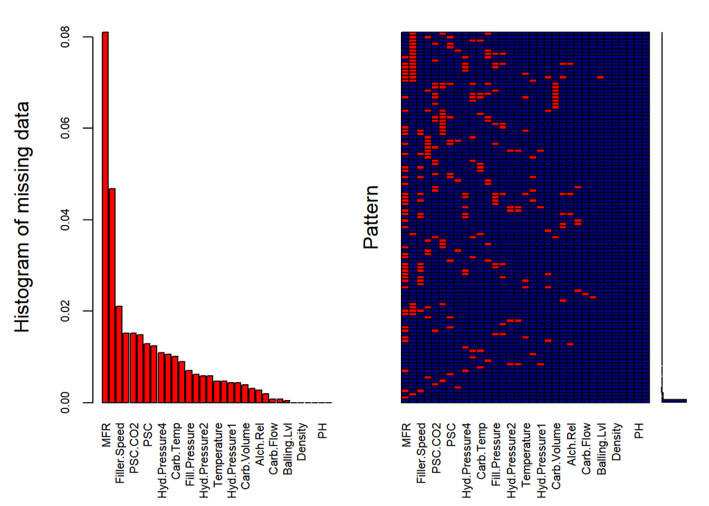

```
##
##  Variables sorted by number of missings:
##           Variable        Count
##                MFR 0.0810284379
##         Brand.Code 0.0467471757
##       Filler.Speed 0.0210362291
##          PC.Volume 0.0151928321
##            PSC.CO2 0.0151928321
##        Fill.Ounces 0.0148032723
##                PSC 0.0128554733
##     Carb.Pressure1 0.0124659135
##      Hyd.Pressure4 0.0109076743
##      Carb.Pressure 0.0105181145
##          Carb.Temp 0.0101285547
##           PSC.Fill 0.0089598753
##      Fill.Pressure 0.0070120764
##       Filler.Level 0.0062329568
##      Hyd.Pressure2 0.0058433970
##      Hyd.Pressure3 0.0058433970
##        Temperature 0.0046747176
##  Pressure.Setpoint 0.0046747176
##      Hyd.Pressure1 0.0042851578
##      Oxygen.Filler 0.0042851578
##        Carb.Volume 0.0038955980
##           Carb.Rel 0.0031164784
##           Alch.Rel 0.0027269186
##         Usage.cont 0.0019477990
##          Carb.Flow 0.0007791196
##      Bowl.Setpoint 0.0007791196
##        Balling.Lvl 0.0003895598
##           Mnf.Flow 0.0000000000
##            Density 0.0000000000
##            Balling 0.0000000000
##    Pressure.Vacuum 0.0000000000
##                 PH 0.0000000000
##      Air.Pressurer 0.0000000000
```

```r
aggr_plot <- aggr(df, col=c('navyblue','red'), numbers=TRUE, sortVars=TRUE, labels=names(data), cex.axis=.7, gap=3, ylab=c("Histogram of missing data","Pattern"))
```

```r
#tempData <- mice(df,m=5,maxit=50,meth='pmm',seed=500)
#summary(tempData)
#completedData <- complete(tempData,1)
#write.csv(completedData, file = "imputeddf.csv")

completedData <- read.csv("imputeddf.csv")
completedData <- completedData[,-1]
```

```r
# for_removal <- caret::nearZeroVar(df)
# for_removal
#
# my_df <- as.data.frame(df)
# for_removal <- caret::nearZeroVar(my_df)
# my_df <- my_df[,-for_removal]
# dim(my_df)
```

## Modeling

- I needed to hot encode (Brand.code), instead i just dropped it. Figure Jun going in whatever direction he chooses anyway, was more just to get an idea of what is happening

### PLS

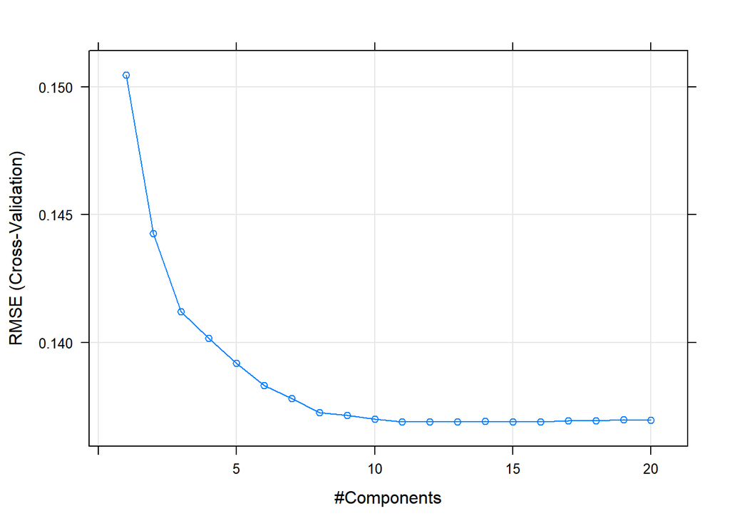

```
##    ncomp
## 13    13
```

```
## [1] 0.1496209
```

### GLMNET

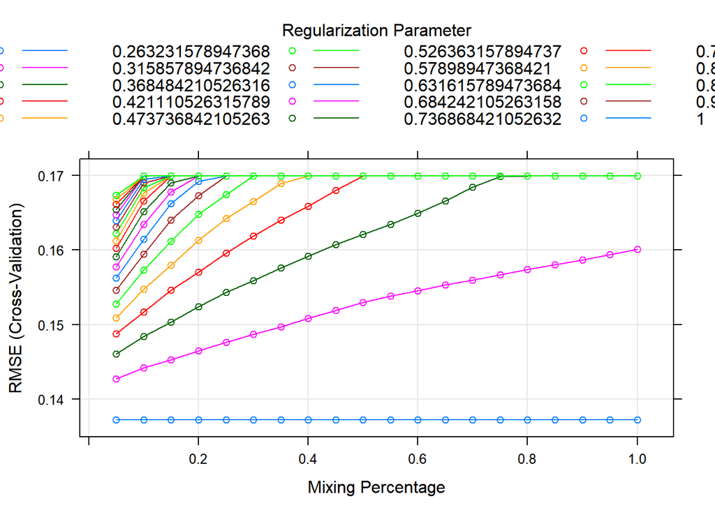

```
##     alpha lambda
## 381     1  1e-04
```

#### Visualize GLMNET

```
##     alpha lambda
## 381     1  1e-04
```

```
## [1] 0.1491899
```

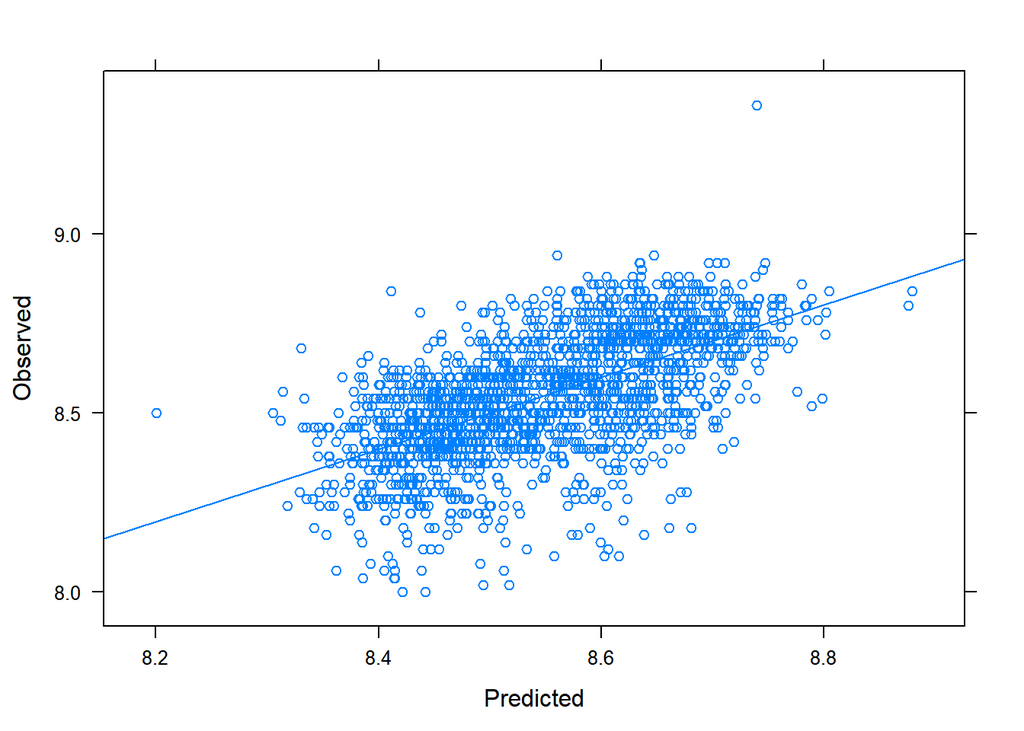

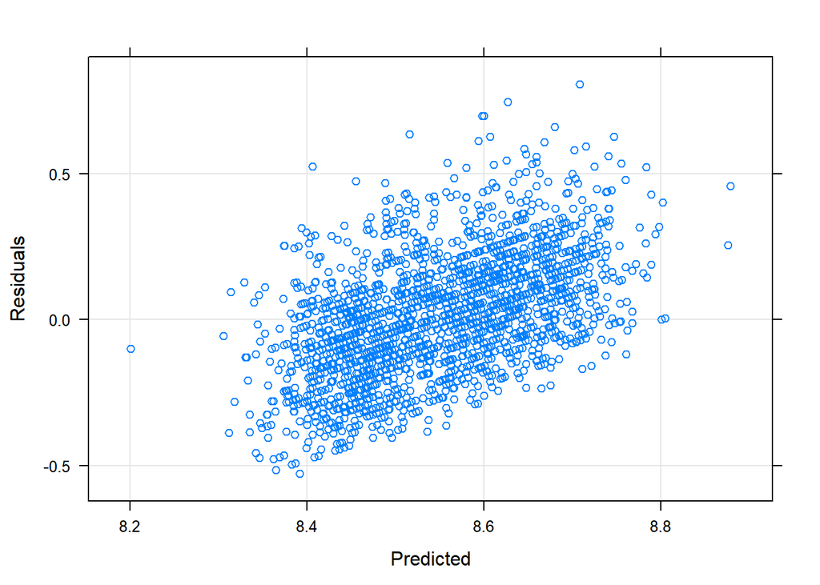

### Full xgboost tree

```r
# smp_size <- floor(0.75 * nrow(completedData))
# train_ind <- sample(seq_len(nrow(completedData)), size = smp_size)
# train <- bb[train_ind, ]
# test <- bb[-train_ind, ]
# train_y <- completedData[train_ind,c('PH')]
# test_y <- completedData[-train_ind,c('PH')]
#
# xgb_trcontrol = trainControl(
#   method = "cv",
#   number = 5,
#   allowParallel = TRUE,
#   verboseIter = FALSE,
#   returnData = FALSE
# )
#
# xgbGrid <- expand.grid(nrounds = c(100,200),
#                        max_depth = c(10, 15, 20, 25,35,50),
#                        colsample_bytree = seq(0.5, 0.9, length.out = 5),
#                        eta = 0.1,
#                        gamma=0,
#                        min_child_weight = 1,
#                        subsample = 1
#                       )
# set.seed(0)
# xgb_model = train(
#   train, train_y,
#   trControl = xgb_trcontrol,
#   tuneGrid = xgbGrid,
#   method = "xgbTree")
```

#### Visualize xgboost

```r
#save(xgb_model, file = "PH_model1.rda")
load("PH_model1.rda")
set.seed(123)


xgb_model$bestTune
```

```
##    nrounds max_depth eta gamma colsample_bytree min_child_weight subsample
## 12     200        15 0.1     0              0.5                1         1
```

```r
predicted = predict(xgb_model, test)
residuals = test_y - predicted
RMSE(predicted, test_y)
```

```
## [1] 0.117223
```

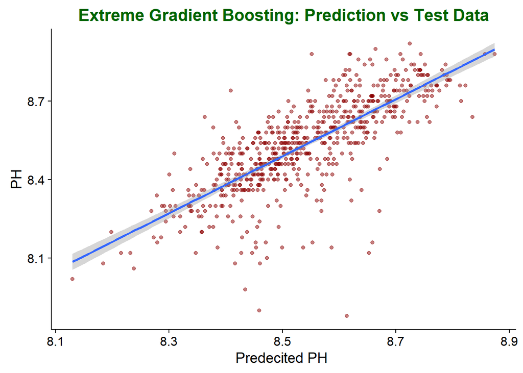

```r
my_data = as.data.frame(cbind(predicted = predicted,
                            observed = test_y))
# Plot predictions vs test data
ggplot(my_data,aes(predicted, test_y)) + geom_point(color = "darkred", alpha = 0.5) +
    geom_smooth(method=lm)+ ggtitle('Linear Regression ') + ggtitle("Extreme Gradient Boosting: Prediction vs Test Data") +
      xlab("Predecited PH ") + ylab("PH") +
        theme(plot.title = element_text(color="darkgreen",size=16,hjust = 0.5),
         axis.text.y = element_text(size=12), axis.text.x = element_text(size=12,hjust=.5),
         axis.title.x = element_text(size=14), axis.title.y = element_text(size=14))
```

```r
# col_index <- varImp(xgb_model)$importance %>%
#   mutate(names=row.names(.)) %>%
#   arrange(-Overall)
# col_index$names
#write.csv(col_index,"full_tree.csv")
```

### Variable importance

- pls, elastic net, xgboost

```r
varImp(lmFit1)
```

```
## pls variable importance
##
##   only 20 most important variables shown (out of 31)
##
##                   Overall
## Mnf.Flow           100.00
## Usage.cont          65.22
## Bowl.Setpoint       61.71
## Hyd.Pressure3       54.87
## Filler.Level        51.75
## Temperature         50.58
## Pressure.Setpoint   44.91
## Hyd.Pressure2       41.84
## Fill.Pressure       39.54
## Carb.Pressure1      39.07
## Pressure.Vacuum     32.79
## Hyd.Pressure4       29.98
## Carb.Flow           29.54
## Oxygen.Filler       28.93
## Fill.Ounces         28.50
## Alch.Rel            26.02
## Density             22.36
## PSC                 20.26
## Carb.Rel            19.01
## Hyd.Pressure1       18.83
```

```r
varImp(model)
```

```
## glmnet variable importance
##
##   only 20 most important variables shown (out of 31)
##
##                    Overall
## Oxygen.Filler     100.0000
## Density            47.4890
## PSC.CO2            44.8748
## Alch.Rel           36.7271
## PSC                33.8469
## Fill.Ounces        31.8064
## PC.Volume          21.1337
## PSC.Fill           14.8922
## Balling            14.7425
## Balling.Lvl        14.3287
## Carb.Volume        13.5275
## Carb.Rel            6.0500
## Temperature         5.9405
## Pressure.Setpoint   2.7717
## Usage.cont          2.2711
## Carb.Pressure1      2.2437
## Pressure.Vacuum     1.1567
## Hyd.Pressure3       1.1243
## Bowl.Setpoint       1.0981
## Carb.Temp           0.7988
```

```r
varImp(xgb_model)
```

```
## xgbTree variable importance
##
##   only 20 most important variables shown (out of 31)
##
##                 Overall
## Mnf.Flow         100.00
## Usage.cont        54.37
## Temperature       38.81
## Pressure.Vacuum   35.93
## Balling.Lvl       35.42
## Carb.Flow         35.17
## Filler.Speed      33.71
## Oxygen.Filler     32.77
## Carb.Rel          32.49
## Alch.Rel          32.20
## Carb.Volume       25.82
## Bowl.Setpoint     24.88
## Filler.Level      24.46
## Balling           22.56
## Density           22.16
## Carb.Pressure1    21.73
## Fill.Ounces       19.33
## Hyd.Pressure1     16.18
## Carb.Pressure     11.32
## MFR               10.08
```

## Run models without collinearity issues

- didnt get to this yet, but maybe i can run some models in subsetted dataset, while Jun chooses to run on entire dataset?

```r
# smp_size <- floor(0.75 * nrow(completedData))
# train_ind <- sample(seq_len(nrow(completedData)), size = smp_size)
# train <- bb[train_ind,-c(31,29) ]
# test <- bb[-train_ind,-c(31,29) ]
# train_y <- completedData[train_ind,c('PH')]
# test_y <- completedData[-train_ind,c('PH')]
#
# xgb_trcontrol = trainControl(
#   method = "cv",
#   number = 5,
#   allowParallel = TRUE,
#   verboseIter = FALSE,
#   returnData = FALSE
# )
#
# xgbGrid <- expand.grid(nrounds = c(100,200),
#                        max_depth = c(10, 15, 20, 25,35,50),
#                        colsample_bytree = seq(0.5, 0.9, length.out = 5),
#                        eta = 0.1,
#                        gamma=0,
#                        min_child_weight = 1,
#                        subsample = 1
#                       )
# set.seed(0)
# xgb_model = train(
#   train, train_y,
#   trControl = xgb_trcontrol,
#   tuneGrid = xgbGrid,
#   method = "xgbTree")
```

### Caret ensemble

- wasn’t working

```r
# completedData <- read.csv("imputed.csv")
# complete_df_imputed <- completedData
#
# complete_df_imputed <- complete_df_imputed[,-1]
# set.seed(123)
# smp_size <- floor(0.75 * nrow(complete_df_imputed))
# train_ind <- sample(seq_len(nrow(complete_df_imputed)), size = smp_size)
# train <- bb[train_ind,-1 ]
# test <- bb[-train_ind,-1 ]
# train_y <- completedData[train_ind,c('PH')]
# test_y <- completedData[-train_ind,c('PH')]
#
#
#
# library(doParallel)
# library(caret)
# registerDoParallel(4)
# getDoParWorkers()
#
# set.seed(123)
# my_control <- trainControl(method = 'cv', # for âcross-validationâ
#                            number = 3, # number of k-folds
#                            savePredictions = 'final',
#                            allowParallel = TRUE)
#
# model_list <- caretList(train,
#                         train_y,
#                         trControl = my_control,
#                         methodList = c('lm', 'svmRadial', 'rf',"pls",
#                                        'xgbTree', 'xgbLinear',"bagEarth",'glmnet',"knn" ),
#                         tuneList = NULL,
#                         continue_on_fail = FALSE,
#                         preProcess = c('center','scale'))
#
# options(digits = 3)
# model_results <- data.frame(LM = min(model_list$lm$results$RMSE),
#  SVM = min(model_list$svmRadial$results$RMSE),
#  RF = min(model_list$rf$results$RMSE),
#  XGBT = min(model_list$xgbTree$results$RMSE),
#  XGBL = min(model_list$xgbLinear$results$RMSE),
#  Mars = min(model_list$bagEarth$results$RMSE),
#  GLMNET = min(model_list$glmnet$results$RMSE),
#  PLS =min(model_list$pls$results$RMSE),
#  KNN =min(model_list$knn$results$RMSE))
#
# print(model_results)
```

### Jun’s Code

- this isn’t Jun’s complete slack code. I added it becuase i wanted to take a look at the functions he posted to slack

```r
# train <- readxl::read_excel('Data//StudentData.xlsx')
# eval <- readxl::read_excel('Data//StudentEvaluation.xlsx')
#
# # Summary stats table
# summary_stats <- function(df){
#   minimum <- round(apply(df, 2, min, na.rm=T),2)
#   maximum <- round(apply(df, 2, max, na.rm=T),2)
#   quantile1 <- round(apply(df, 2, quantile, 0.25, na.rm=T),2)
#   quantile3 <- round(apply(df, 2, quantile, 0.75, na.rm=T),2)
#   medians <- round(apply(df, 2, median, na.rm=T),2)
#   means <- round(apply(df, 2, mean, na.rm=T),2)
#   stdev <- round(apply(df, 2, sd, na.rm=T),2)
#   nas <- apply(apply(df, 2, is.na), 2, sum, na.rm=T)
#   nas_p <- paste(round(nas / dim(df)[1], 4) * 100, '%')
#   temp <- data.frame(means, stdev, minimum, maximum, quantile1, medians, quantile3, nas, nas_p)
#   colnames(temp) <- c('Mean', 'St.Dev', 'Min.', 'Max.', '1st.Qu.', 'Median', '3rd.Qu.', "NA", "% NA")
#   return(temp)
# }
# df$Brand.Code
# # Summary stats for train and eval sets
# train_summary <- df %>% subset(select=-c(Brand.Code)) %>% summary_stats()
# eval_summary <- eval %>% subset(select=-c(Brand.Code, PH)) %>% summary_stats()
# train_summary
# eval_summary
```